# extending-the-Pareto

```
## Data was last updated on 2025-04-29
```

## Background

1. Mass $m$ follows a truncated Pareto PDF as defined by White et al. 2008:

$$f(m) = \frac{(\lambda +
1)m^{\lambda}}{m_{max}^{\lambda + 1} - m_{min}^{\lambda +
1}}$$

2. We observed $n$ individuals sampled in the interval [$m_{min}$,$m_{max}$].
3. We want to estimate the new total expected abundance, $N_{new}$, in the extended interval [$m_{min2}$,$m_{max}$], where $m_{min2} < m_{min}$

## Deriving $N_{new}$ using PDF normalization

1. Define the total count in [$m_{min}$,$m_{max}$] as the integral of a density count function, $N(m) = cm^{\lambda}$:

$$n = \int_{m_{min}}^{m_{max}}
cm^{\lambda} dm$$
where, $c$ is the density normalizer. The density normalizer simply converts the probability density function into a count density function as:

$$c = n \frac{(\lambda +
1)}{m_{max}^{\lambda + 1} - m_{min}^{\lambda +1}}$$

as such, $c$ is directly proportional to $n$. Therefore, if we have adequately sampled the community from which we are estimating $\lambda$ and have well defined bounds on the mass range, $[m_{min},m_{max}]$, $c$ acts as a location parameter to scale community abundance or biomass across samples. These two community properties scale with $c$ linearly as:

Abundance

$$\frac{dN}{dc} =
\frac{x_{max}^{\lambda+1} - x_{min}^{\lambda + 1}}{\lambda + 1}$$
Biomass

$$\frac{dB}{dc} = \frac{x_{max}^{\lambda+2} -
x_{min}^{\lambda + 2}}{\lambda + 2}$$

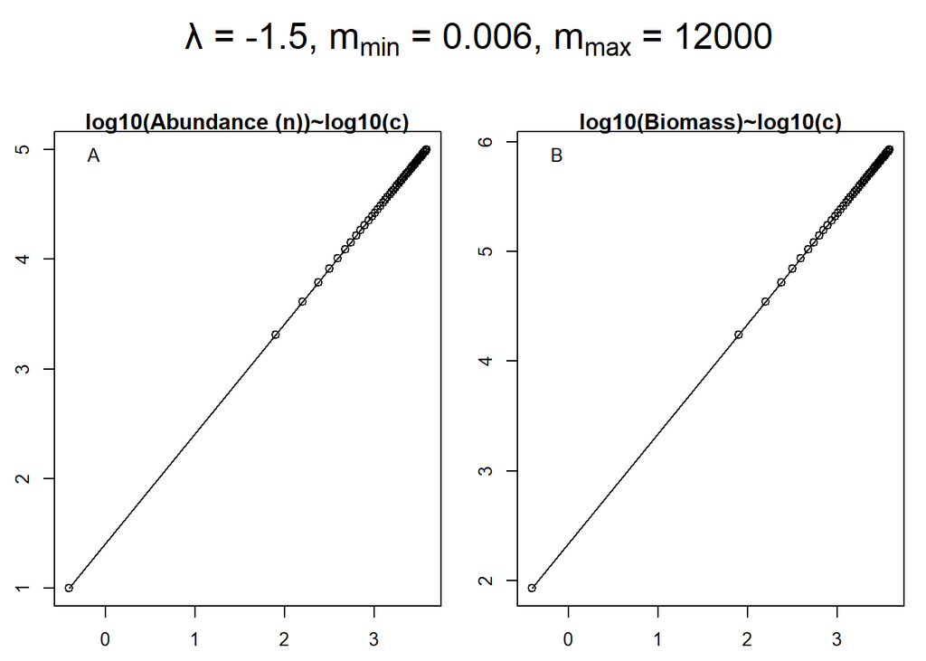

Figure X. The relationship between the normalization constant ‘c’ and A) total community abundance or B) total community biomass’. These properties scale linearly for a given lambda, minimum mass, and maximum mass. The example shown has a fixed lambda = -1.5, minimum mass = 0.006 mg, and maximum mass = 12,000 mg.

As an aside, if we want to compare communities and find a replacement of the ‘height’ parameter (often just the intercept of the log-log relationship between log(N) ~ log(m)), $c$ isn’t a great candidate because it is dependent on $\lambda$, $m_{min}$, and $m_{max}$. Therefore a it is probably best to suggest that a reference mass, $m_0$, is used (e.g., $m_0 = 1 mg$). This is equally as arbitrary as the intercept (in this example they are the same), but at least it is explicit and in theory you could convert across different mass measurements across studies (e.g., studies with mass in grams vs milligrams) using these relationships.

Now back to adjusting our abundance to a new $m_{min}$ for undersampling. The next step is to,

2. Evaluate the integral:

$$n = c \cdot \frac{m_{max}^{\lambda + 1}
- m_{min}^{\lambda + 1}}{\lambda + 1} \Rightarrow c = n \frac{\lambda +
1}{m_{max}^{\lambda + 1} - m_{min}^{\lambda + 1}}$$

3. The expected number in [$m_{min2}$,$m_{max}$] is:

$$N_{new} = \int_{m_{min2}}^{m_{max}}
cm^{\lambda} dm = c \cdot \frac{m_{max}^{\lambda + 1} -
m_{min2}^{\lambda + 1}}{\lambda + 1}$$

4. Substitute $c$ from step 2:

$$N_{new} = [n \frac{\lambda +
1}{m_{max}^{\lambda + 1} - m_{min}^{\lambda + 1}}] \cdot
\frac{m_{max}^{\lambda + 1} - m_{min2}^{\lambda + 1}}{\lambda +
1}$$
which simplifies to:

$$N_{new} = n \cdot \frac{m_{max}^{\lambda
+ 1} - m_{min2}^{\lambda + 1}}{m_{max}^{\lambda + 1} - m_{min}^{\lambda
+ 1}}$$

## Caveats and assumptions

- This is the expected count if we extrapolate the Pareto function outside the [$m_{min}$,$m_{max}$] range, this assumed that the $\lambda$ fit is valid below this range. I think we are justified in this assumption if we keep it to a reasonable $m_{min2}$.

## Application

Here, given the assumptions above, we want to apply this to undersampled data. Moving forward, I suggest we take the following approach.

1. We have a sample of $N_{orig}$ individual masses, *$M$*, within the range [$m_{orig}$,$m_{max}$]. We know there is some undersampling of individuals at some mass, $m_{cutoff}$.
2. We estimate $m_{cutoff}$ with `estimate_xmin()` in the `powRlaw` package.
3. This leaves us a new sample of $N_{cutoff}$ individuals masses, *$M_{cutoff}$*, within the new range, [$m_{cutoff}$, $m_{max}$].
4. We apply the above procedure to estimate $N_{new}$, which is the estimated abundance within the range [$m_{orig}$, $m_{max}$], corrected for undersampling.
5. First, we estimate $\lambda$ based on the *$M_{cutoff}$* sample in the range [$m_{cutoff}$,$m_{max}$].
6. Then, we have the measured abundance in the cutoff interval, $N_{cutoff}$, that we can put into the equation above to estimate $N_{new}$ as:

7. It is possible that we could add this into `isdBayes` to allow incorporating the uncertainty in $\lambda$ and $m_{cutoff}$ to get uncertainty in the $N_{new}$. Within a sample, $N_{cutoff}$ is “known”, and I think we would have to think more about how these are distributed, but as an example if we could use bootstrapping to define the distribution of $m_{cutoff} \sim N(\mu_{m_{cutoff}}, \sigma_{m_{cutoff}})$ and if similarly we have $\lambda \sim N(\mu_{\lambda}, \sigma_{\lambda})$ we should be able to generate a posterior for this estimate. I know this is likely missing some important information as $m_{cutoff}$ and $\lambda$ are not really independent, but this could be a way forward for now??? Or maybe we just incorporate the $\lambda$ uncertainty for the time being?